# Gas Heating Efficiencies of Massachusetts Communities

mike

4/3/2022

# Introduction

The Commonwealth of Massachusetts has set ambitious targets for decarbonization which will include *electrifying* thermal energy sources used for common tasks such as building heating, water heating, and cooking. This analysis provides a summary for each community that illustrates key performance metrics that will inform each community’s pathway to decarbonization by performing a simple heating degree day regression against gas use data published via the [MassSave Data Portal](https://www.masssavedata.com/Public/GeographicSavings?view=C).

#### Outputs Include:

- **Community Response** to changes in Heating Degree Days (HDD) in terms of therms per household
- **Comparative Ranking** of communities indicating the aggregate thermal efficiencicy of residences
- **Base Level** natural gas consumption indicating the percentage of consumption from weather independent uses
- **AND MORE**

## Applications

1. Reducing CO<sub>2</sub>
2. Stabilizing the Climate!

## Week 3 Learnings!

1. Took a bit more time to get started as i decided i should reinstall base R from when i originally attempted to pick this up ~v3.6. This seems to have cleared up some consitent error messages.
2. This was a bear! I tried many different options to get the number values with commas to import as numbers instead of char. These included trying to use gsub to replace “,”, “” and other overly-complicated things. Ultimately i recalled the col_types lesson from week2 (seems like ages ago) and got that to work well. Also found the problems() function in the console to be helpful in troubleshooting.

skim was handy for looking at the results. The histograms seem off, but then i realized that i have an extreme outlyer on the large end of the spectrum that is the sum of all communities.

## What’s Next for this project??

Ultimately i hope to join in two additional datasets for community population and a matching value for monthly heating degree days for each observation.

I believe i will need to change the shape of the set to get the month columns condensed into a row value.

I want to then run simple regression on therms/population as dependent on heating degree days. I would like to batch this process so that the regression is performed on each location separately, likely dropping the commercial sector values to start. I realize regression isn’t part of the curriculum here, but i think i can make it work.

```
## # A tibble: 7,392 x 16
##    location sector  year    jan    feb    mar    apr    may    jun    jul    aug
##    <chr>    <chr>  <dbl>  <dbl>  <dbl>  <dbl>  <dbl>  <dbl>  <dbl>  <dbl>  <dbl>
##  1 Chelsea  Comme~  2017 1.00e6 895737 1.03e6 655966 504521 379688 320987 348145
##  2 West Sp~ Resid~  2016 1.00e6 922822 6.81e5 481369 242352 137111 120771 115861
##  3 Harwich  Total   2013 1.00e6 946091 7.80e5 501764 311611 220656 199072 196173
##  4 Weston   Resid~  2017 1.00e6 835067 8.40e5 508196 294608 183613 136922 147613
##  5 Shrewsb~ Comme~  2019 1.00e6 867168 7.99e5 519649 339710 225549 203106 240462
##  6 Dartmou~ Resid~  2019 1.00e6 782620 7.23e5 382475 253353 129299 103476 100700
##  7 Sharon   Resid~  2014 1.00e6 936024 8.36e5 427850 207622 120141  99278  99960
##  8 Ludlow   Total   2015 1.01e6 940980 6.69e5 138985 159480 104639  98044  97711
##  9 Swansea  Total   2018 1.01e6 732518 8.13e5 593640 255046 137231 103613 101758
## 10 Braintr~ Resid~  2017 1.01e6 885954 8.15e5 518474 265474 157230 117096 117200
## # ... with 7,382 more rows, and 5 more variables: sept <dbl>, oct <dbl>,
## #   nov <dbl>, dec <dbl>, annual <dbl>
```

Data summary

| Name | ma_hdd |
| --- | --- |
| Number of rows | 7392 |
| Number of columns | 16 |
| _______________________ |  |
| Column type frequency: |  |
| character | 2 |
| numeric | 14 |
| ________________________ |  |
| Group variables | None |

**Variable type: character**

| skim_variable | n_missing | complete_rate | min | max | empty | n_unique | whitespace |
| --- | --- | --- | --- | --- | --- | --- | --- |
| location | 0 | 1 | 3 | 16 | 0 | 352 | 0 |
| sector | 0 | 1 | 5 | 23 | 0 | 3 | 0 |

**Variable type: numeric**

| skim_variable | n_missing | complete_rate | mean | sd | p0 | p25 | p50 | p75 | p100 | hist |
| --- | --- | --- | --- | --- | --- | --- | --- | --- | --- | --- |
| year | 0 | 1.0 | 2016.0 | 2 | 2013 | 2014.0 | 2016 | 2018.0 | 2019 | ▇▃▃▃▇ |
| jan | 2233 | 0.7 | 2335312.3 | 19671989 | 395 | 206507.5 | 537424 | 1254587.0 | 483268123 | ▇▁▁▁▁ |
| feb | 2235 | 0.7 | 2000746.3 | 16856282 | 398 | 175890.0 | 453839 | 1057108.0 | 442304367 | ▇▁▁▁▁ |
| mar | 2235 | 0.7 | 1858559.6 | 15632703 | 512 | 160975.0 | 423236 | 973162.0 | 365600259 | ▇▁▁▁▁ |
| apr | 2235 | 0.7 | 1187243.7 | 9989052 | 482 | 100235.0 | 259011 | 593640.0 | 245253760 | ▇▁▁▁▁ |
| may | 2235 | 0.7 | 707762.6 | 6047511 | 225 | 54920.0 | 152070 | 345940.0 | 157490893 | ▇▁▁▁▁ |
| jun | 2235 | 0.7 | 513773.6 | 4464123 | 101 | 32973.0 | 99550 | 225700.0 | 107034922 | ▇▁▁▁▁ |
| jul | 2235 | 0.7 | 457881.2 | 4022564 | 117 | 27208.0 | 82608 | 192889.0 | 92610793 | ▇▁▁▁▁ |
| aug | 2235 | 0.7 | 469889.1 | 4145655 | 110 | 27634.0 | 84858 | 197011.0 | 95146760 | ▇▁▁▁▁ |
| sept | 2235 | 0.7 | 503936.4 | 4400364 | 126 | 32305.0 | 94337 | 216676.0 | 101220049 | ▇▁▁▁▁ |
| oct | 2235 | 0.7 | 832083.3 | 7088103 | 224 | 65652.0 | 178023 | 404627.0 | 184842206 | ▇▁▁▁▁ |
| nov | 2233 | 0.7 | 1429535.0 | 12080508 | 7 | 122554.5 | 316263 | 745864.5 | 312440502 | ▇▁▁▁▁ |
| dec | 2232 | 0.7 | 2090789.2 | 17640596 | 938 | 179766.5 | 475426 | 1111436.0 | 433155712 | ▇▁▁▁▁ |
| annual | 2232 | 0.7 | 14381839.2 | 121037372 | 6476 | 1242767.0 | 3234532 | 7312978.5 | 2826920366 | ▇▁▁▁▁ |

[output not shown]

[output cut: 19986 more lines]

Data summary

| Name | ma_hdd_fin2 |
| --- | --- |
| Number of rows | 88704 |
| Number of columns | 5 |
| _______________________ |  |
| Column type frequency: |  |
| character | 2 |
| factor | 1 |
| numeric | 2 |
| ________________________ |  |
| Group variables | None |

**Variable type: character**

| skim_variable | n_missing | complete_rate | min | max | empty | n_unique | whitespace |
| --- | --- | --- | --- | --- | --- | --- | --- |
| location | 0 | 1 | 3 | 16 | 0 | 351 | 0 |
| sector | 0 | 1 | 5 | 23 | 0 | 3 | 0 |

**Variable type: factor**

| skim_variable | n_missing | complete_rate | ordered | n_unique | top_counts |
| --- | --- | --- | --- | --- | --- |
| month | 0 | 1 | FALSE | 13 | jan: 7371, feb: 7371, mar: 7371, apr: 7371 |

**Variable type: numeric**

| skim_variable | n_missing | complete_rate | mean | sd | p0 | p25 | p50 | p75 | p100 | hist |
| --- | --- | --- | --- | --- | --- | --- | --- | --- | --- | --- |
| year | 0 | 1.0 | 2016.0 | 2 | 2013 | 2014 | 2016 | 2018 | 2019 | ▇▃▅▅▇ |
| value | 26813 | 0.7 | 623377.2 | 1829417 | 7 | 65814 | 202638 | 560780 | 51800281 | ▇▁▁▁▁ |

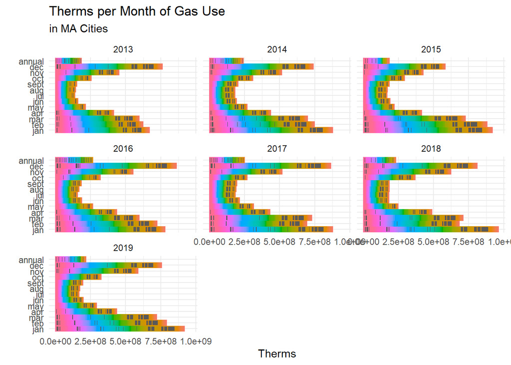